# 肺炎可视化

李誉辉

2020年1月27日

# 1 简介

[丁香园·丁香医生](https://3g.dxy.cn/newh5/view/pneumonia?from=timeline&isappinstalled=0)

**数据介绍:**

该数据是从[丁香园·丁香医生](https://3g.dxy.cn/newh5/view/pneumonia?from=timeline&isappinstalled=0)通过爬虫获取的全国2019-ncov病毒的感染病例。

# 2 需要的包

```
devtools::install_github("microly/alimap")
```

```r
library(alimap) # to get China map at the prefecture city level
library(sf)
library(ggplot2)
library(dplyr)
library(tibble)
library(tidyr)
library(magrittr)
library(purrr)
library(readr)
library(stringr)
library(gganimate)
library(lubridate)
library(Cairo)
library(magick)
library(RColorBrewer)
```

# 3 地图数据

如果有本地数据，可以自行读取。  
因为很多市级地名存在变化，  
而且爬取的比较乱，部分没有“市”这个字，  
所以使用前2个汉字进行联结表。以地图数据集中的城市名为准。

```r
Chinamap_cities_sf <- map_prefecture_city() %>%
  mutate(c2 = str_sub(name, 1, 2))
```

# 4 时间序列

每12小时更新1次，从早上9点到晚上9点。

```r
# set start day
startTime <- ymd_h("2020/1/25 21", tz="Asia/Shanghai")
nowTime <- Sys.time() %>% with_tz(tz="Asia/Shanghai") # only support Shanghai timezone
timeLength <- interval(startTime, nowTime) %>%
  time_length("hour") %>% `%/%`(12)
endTime <- startTime + dhours(timeLength*12)
# time sequence
mytime <- startTime + dhours(12*(0:timeLength)) %>% .[-6] # 404 at the time
mymonth <- month(mytime)
myday <- day(mytime)
myhour <- hour(mytime) %>% as.character() %>%
  str_pad(width = 2, side = "left", pad = "0") # make character string same length

myAPI <- paste(date(mytime), myhour, sep = "T")
```

# 5 疫情数据

通过API接口读取疫情历史数据，API接口由网友提供，爬取自丁香园。

```r
# define a function to read epidemic data of a day
read_epidemic <- function(oneAPI) {
  url_API <- paste0("http://69.171.70.18:5000/download/city_level_", oneAPI, ".csv")
  epidemic_df <- read_csv(file = url_API)
  colnames(epidemic_df) <- c("x1","unnamed", "city", "confirmed_c", "suspected_c",
                             "cured_c", "dead_c", "province", "short_p", "confirmed_p",
                             "suspected_p", "cured_p", "dead_p", "comment")
  epidemic_df %<>% select(city, confirmed_c)
  return(epidemic_df)
}


epidemic_nest <- tibble(time = mytime,
                        myAPI = myAPI) %>%
  mutate(., data = map(.$myAPI, ~read_epidemic(.x))) %>%
  select(-myAPI) %>% unnest()
```

# 6 分箱

因为很多市级地名存在变化，  
而且爬取的比较乱，部分没有“市”这个字，  
所以使用前2个汉字进行联结表。以地图数据集中的城市名为准。

```r
mybreaks <- c(0, 1, 10, 50, 100, 500, 1000, 5000, 100000)
mylabels <- c("0", "1-9", "10-49", "50-99", "100-499",
              "500-999", "1000-4999", ">=5000")
mypal <- c("white", brewer.pal(7, "YlOrRd"))

epidemic_df <- epidemic_nest %>%
  mutate(conf2 = cut(confirmed_c, breaks = mybreaks,
                     labels = mylabels, include.lowest = TRUE,
                     right = FALSE, ordered_result = TRUE)) %>%
  mutate(c2 = str_sub(city, 1, 2))
```

# 7 联结表及循环绘图

```r
# create temporary document
dir.create(dir1 <- file.path(tempdir(), "testdir"))

for (i in 1:length(mytime)) {
  # join epidemic data with map data
  epidemic_time <- epidemic_df %>% filter(time == mytime[i])
  epidemic_city <- Chinamap_cities_sf %>% left_join(epidemic_time, by = "c2")
  # treatment NA
  conf2 <- epidemic_city$conf2 %>% replace_na(0)
  epidemic_city %<>% select(-c2, -city, -conf2)
  epidemic_city$conf2 <- conf2

  # plot
  gg_epidemic <-  ggplot(epidemic_city) +
    geom_sf(aes(fill = conf2)) +
    coord_sf() +
    scale_fill_manual(values = mypal, limits = mylabels, labels = mylabels) +
    guides(fill = guide_legend(title = "确诊人数", reverse = T)) +
    labs(title = "2019-ncov疫情数据可视化",
        subtitle = mytime[i],
        caption = "数据来源：丁香园·丁香医生") +
    theme(
      # 标题
      plot.title = element_text(face = "bold", hjust = 0.5,
                                color = "black"),
      plot.subtitle = element_text(face = "bold", hjust = 0.5, size = 20,
                                color = "red"),
      plot.caption = element_text(face = "bold", hjust = 1,
                                color = "blue"),
      # 图例
      legend.title = element_text(face = "bold",
                                  color = "black"),
      legend.text = element_text(face = "bold",
                                 color = "black"),
      legend.background = element_rect(colour = "black"),
      legend.key = element_rect(fill = NA), # 图例箱体无背景
      legend.position = c(0.85, 0.2),
      axis.ticks = element_blank(),
      axis.text = element_blank(),
      # 绘图面板
      panel.background = element_blank(),
      panel.border = element_rect(color = "black", linetype = "solid", size = 1, fill = NA)
      )

  # save picture
  ggsave(filename = paste0(date(mytime[i]), "_", hour(mytime[i]), ".png"),
         plot = gg_epidemic, path = dir1,
         width = 20, height = 20, units = "cm")
}
```

# 8 动画

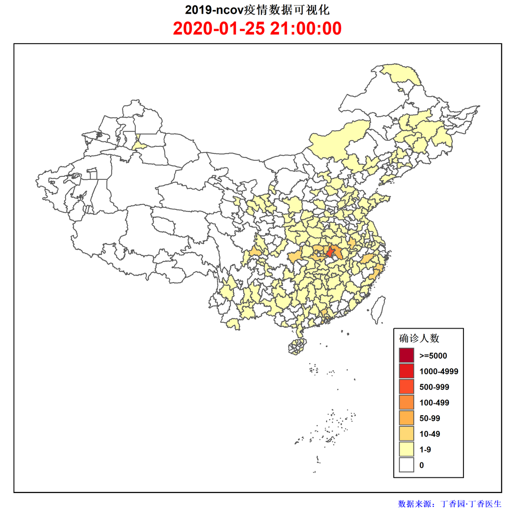

```r
#
path_pre <- "./"
animate_epidemic <-
  image_animate(image = image_read(path = paste0(dir1, "/",
                                            date(mytime), "_", hour(mytime), ".png")),
                fps = 5)

anim_save(filename = "疫情地图可视化动态图.gif",
          animation = animate_epidemic, path = path_pre)

unlink(dir1)
```

**参考来源：**

- [Markdown 入门 & 使用 R + Markdown 发送邮件](https://mp.weixin.qq.com/s/80TiqR2nq3FUQOiz0T_PUg)
- [武汉肺炎疫情数据CSV_实时更新](https://gitlab.com/wybert/open-2019-ncov/tree/master)
- [武汉肺炎（2019-nCoV）数据的R语言接口](https://github.com/microly/data2019ncov)
- [alimap包github](https://github.com/microly/alimap)
- [肺炎地图可视化](https://github.com/zhongjzsb/2019-nCoV/blob/master/visualization.R)